# Lab2

Soyeon Lee

9/9/2020

Problems

1. Use R to demonstrate that the mean minimizes the sum of the squared deviations from the mean. Accomplish the following steps:

(Independence level: 80/100)

```r
# a. Produce a sample of at least 10 or more different numbers
# assign numbers from 1 through 15 into the a vector
# verify the content
scores<-1:15
scores
```

```
##  [1]  1  2  3  4  5  6  7  8  9 10 11 12 13 14 15
```

```r
# b. Produce a simulation following the example from the concepts section
# get the mean of scores
# subtract mean from each of the scores to get deviations
# add all the deviations
mean(scores)
```

```
## [1] 8
```

```r
scores-mean(scores)
```

```
##  [1] -7 -6 -5 -4 -3 -2 -1  0  1  2  3  4  5  6  7
```

```r
sum(scores-mean(scores))
```

```
## [1] 0
```

```r
# c. Use your simulation to test a range of numbers smaller and          larger than the mean to show that the mean minimizes the sum of      the squared deviations from the mean.
#assign the mean of scores to the_mean
#assign all the numbers to numbers_to_test
#set sum_deviations as a null vector to initiate loop
#at each loop, a deviation of each number from the approx.mean are calculated and added as a sum, which is then assigned to each position in sum_deviations
#display sum_deviations
#verify that the_mean is the number that results in sum_deviations=0 when it is suggested as the mean
the_mean<-mean(scores)
numbers_to_test<-min(scores):max(scores)

sum_deviations<-c()
for(i in numbers_to_test){
  sum_deviations[i]<-sum(scores-i)
}
sum_deviations
```

```
##  [1]  105   90   75   60   45   30   15    0  -15  -30  -45  -60  -75  -90 -105
```

```r
the_mean==which(sum_deviations==0)
```

```
## [1] TRUE
```

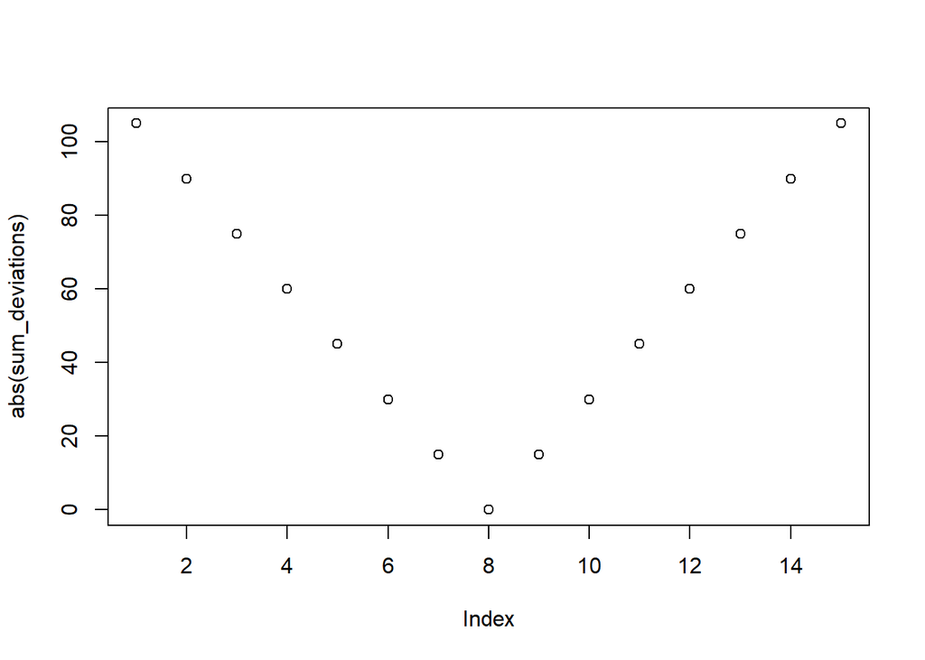

```r
# d. Plot your results.
#transform negatives values as positive to make an easy display of the 0 sum_deviations
plot(abs(sum_deviations))
```

2. Write a custom R function for any one of the following descriptive statistics: median, mode, standard deviation, variance. Demonstrate that it produces the same value as the base R function given some set of numbers.

(Independence level: 100/100)

```r
#name function of scores as variance
#calculate the sum of squared deviations
#calculate the number of numbers for an estimate of population
#verify that the function produces the correct answer

variance<-function(scores){
  ss<-sum((scores-mean(scores))^2)
  n<-length(scores)-1
  return(ss/n)
}
variance(1:5)
```

```
## [1] 2.5
```

```r
var(1:5)
```

```
## [1] 2.5
```

3. Imagine the same instructor taught a morning, afternoon, and evening section of the same course. And, the average scores for each section on a midterm were 85% for the morning, 90% for the afternoon, and 93% for the evening sections. Create a data.frame representing these means for each section. Then, use ggplot2 to plot the means as bar graph. (hint you will need one vector for the class sections, and one vector for the means. Then you can combine them into a data.frame before plotting them)

(Independence level: 80/100)

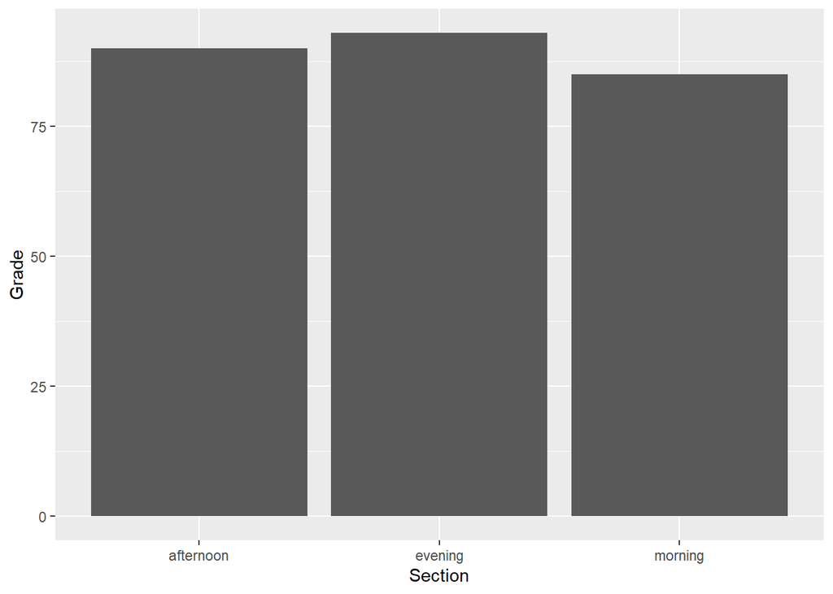

```r
#create sections and grades
#create a new data frame and call it grades_by_section
#plot with x and y variables from the data frame, choose a theme, and include labels and a title
library(ggplot2)

section<-c("morning","afternoon","evening")
grade<-c(85,90,93)
section_grade<-data.frame(section,grade)

ggplot(section_grade,aes(x=section,y=grade))+
  geom_bar(stat="identity")+
  xlab("Section")+
  ylab("Grade")
```

4. Imagine there were two instructors, and they each taught different sections in the morning, afternoon and evening. The midterm averages for instructor 1 were 75%, 78%, and 80% in the morning, afternoon, and evening. The midterm averages for instructor 2 were 88%, 76%, and 63% for the morning, afternoon, and evening. Create a data.frame representing the means, the time of day, and the instructors (three columns). Then plot data.frame using ggplot2 as a bar graph.

(Independence level: 50/100)

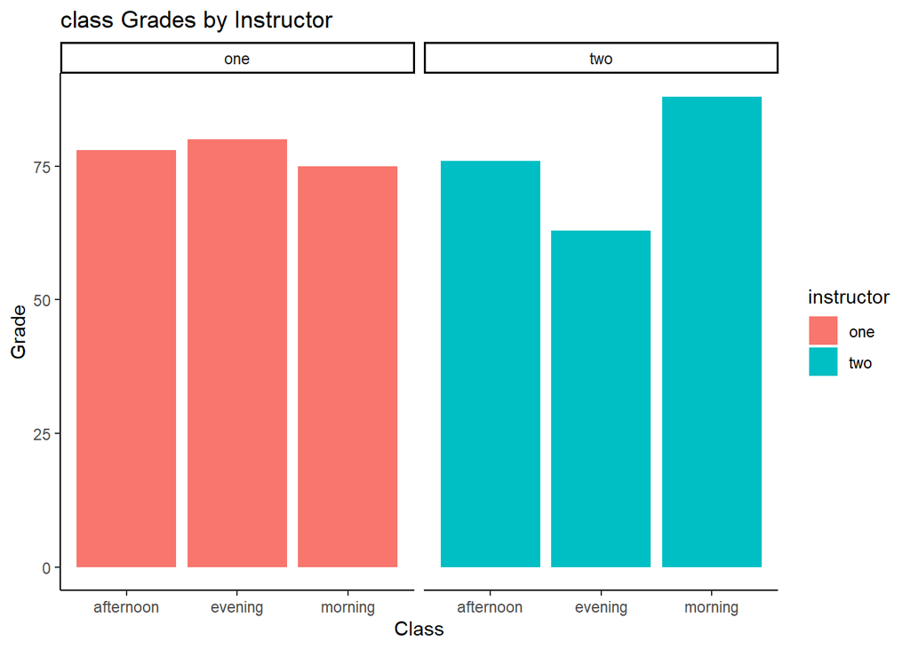

```r
#assign six items to instructor, sections, and grades
#create a data frame called instructor_data
#create a plot for the data, set x and y, and color the bars
#make two sets of graphs with three bars for each instructor and add labels

instructor<-c("one","one","one","two","two","two")
sections<-c("morning","afternoon","evening","morning","afternoon","evening")
grades<-c(75,78,80,88,76,63)

instructor_data<-data.frame(instructor,sections,grades)

ggplot(instructor_data, aes(x=sections,y=grades,group=instructor,fill=instructor))+
  geom_bar(stat="identity")+
  facet_wrap(~instructor)+
  xlab("Class")+
  ylab("Grade")+
  theme_classic()+
  ggtitle("class Grades by Instructor")
```

5. Import the WHR2018.csv data file, containing measure from the World Happiness report from 2018. For the years 2010 to 2015, what was the mean “healthy life expectancy at birth” for each year (find the mean for each year across countries). Show your results in a table and in a graph using ggplot. (Independence level: 40/100)

```r
#load the data and name it
#create a subset data called group_means
#filter out all years except 2010-2015
#summarize mean life expectancy by year across all countries, while removing the entry that has no information

world_happiness<-read.table("open_data/WHR2018.csv",sep=",",header=TRUE)

library(dplyr)
```

```r
library(ggplot2)
group_means<-world_happiness%>%
  filter(year>=2010,
         year<=2015)%>%
  group_by(year)%>%
  summarize(mean_LifeExp=mean(Healthy.life.expectancy.at.birth, na.rm=TRUE))
knitr::kable(group_means)
```

| year | mean_LifeExp |
| --- | --- |
| 2010 | 62.53840 |
| 2011 | 61.73150 |
| 2012 | 62.71080 |
| 2013 | 62.73205 |
| 2014 | 62.70065 |
| 2015 | 62.97737 |

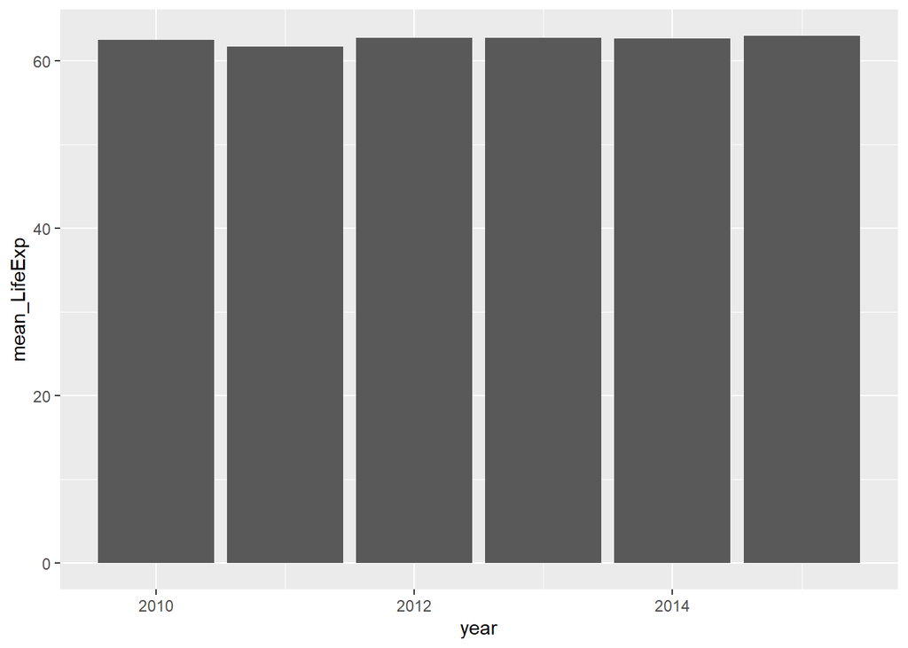

```r
ggplot(group_means,aes(x=year,y=mean_LifeExp))+geom_bar(stat="identity")
```

6. Repeat the above, except in addition to calculating the mean for each year, also calculate the standard deviation for “healthy life expectancy at birth” for each year. Then, add error bars to your graph using the +1 and -1 standard deviations from the means for each year. (Independence level: 80/100)

```r
#create group_means subset data and group_by year
#filter out NA entries for Healthy.life.expectancy.at.birth, and only keep those from years 2010-2015
#summarize the mean and the standard deviation
#create a table
#create a bar graph, label x and y variables, and add in the error bars to show 1 standard deviation around the mean

group_means<-world_happiness%>%
  group_by(year)%>%
  filter(!is.na(Healthy.life.expectancy.at.birth),year>=2010,year<=2015)%>%
  summarize(mean_LifExp=mean(Healthy.life.expectancy.at.birth),sd_LifExp=sd(Healthy.life.expectancy.at.birth))
knitr::kable(group_means)
```

| year | mean_LifExp | sd_LifExp |
| --- | --- | --- |
| 2010 | 62.53840 | 7.873946 |
| 2011 | 61.73150 | 8.111597 |
| 2012 | 62.71080 | 7.338667 |
| 2013 | 62.73205 | 7.508136 |
| 2014 | 62.70065 | 7.696099 |
| 2015 | 62.97737 | 7.639567 |

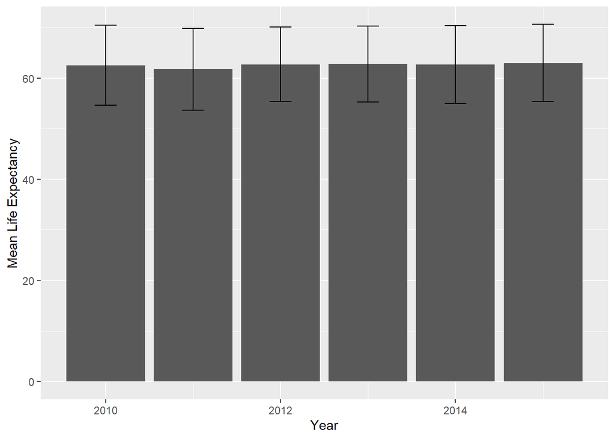

```r
ggplot(group_means,aes(x=year,y=mean_LifExp))+
  geom_col()+
    ylab("Mean Life Expectancy")+
    xlab("Year")+
  geom_errorbar(aes(ymin=mean_LifExp-sd_LifExp,
                    ymax=mean_LifExp+sd_LifExp),width=.25)
```

Advanced

The mean minimizes the sum of the squared deviations. The median minimizes the sum of the absolute deviations. Demonstrate these properties by simulation in R.

Create a set of numbers where the mean and median are different. Then show a plot of values around the mean and the median showing that the mean minimizes the sum of the squared deviations. Finally, create a plot of values around the mean and the median showing that the median minimizes the sum of the absolute deviations.

```r
#create a vector of numbers
#define the length of loop by identifying the min and the max numbers, then assign it to a variable
#create null vectors
#create a for loop that calculates the sum of squared deviations and sum of absolute deviations, then store them in vectors
#verify the contents in each vector
#plot each vector showing the minimum values
scores<-c(3,5,7,4,7,8,9,1)

nums_test<-seq(min(scores),max(scores),.5)
sum_sq_dv<-c()
sum_abs_dv<-c()

for(i in nums_test){
  sum_sq_dv[i]<-sum((i-mean(scores))^2)
  sum_abs_dv[i]<-sum(abs(i-median(scores)))
}

sum_sq_dv
```

```
## [1] 16.00  9.00  4.00  1.00  0.00  1.00  4.00  9.00 12.25
```

```r
sum_abs_dv
```

```
## [1] 4.5 3.5 2.5 1.5 0.5 0.5 1.5 2.5 3.0
```

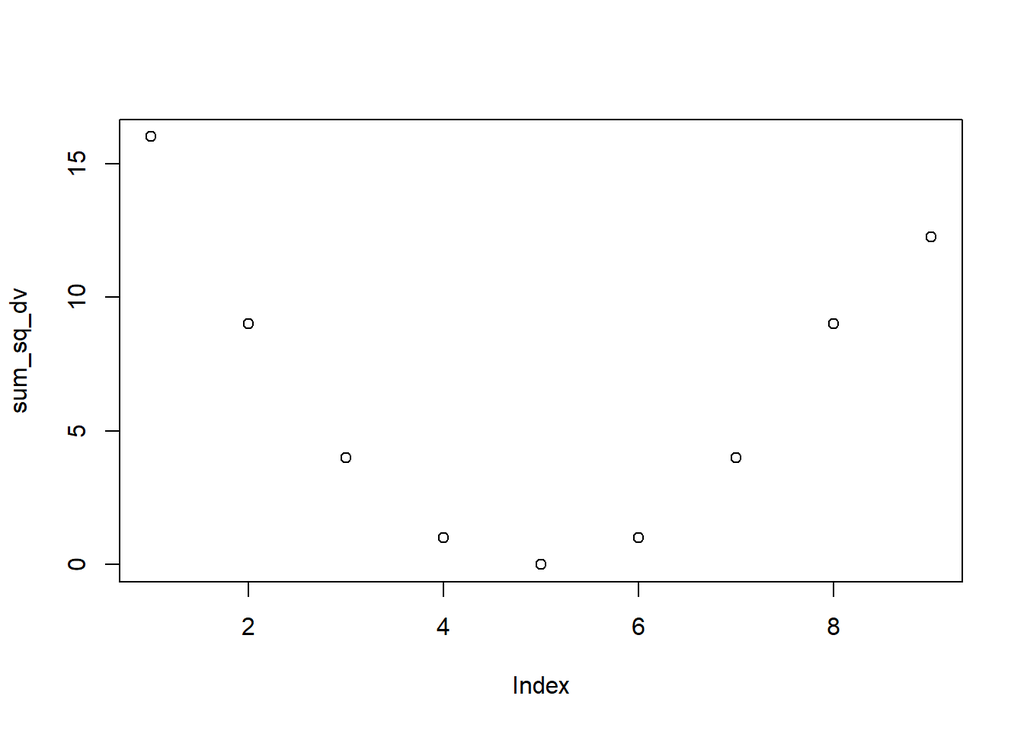

```r
plot(sum_sq_dv)
```

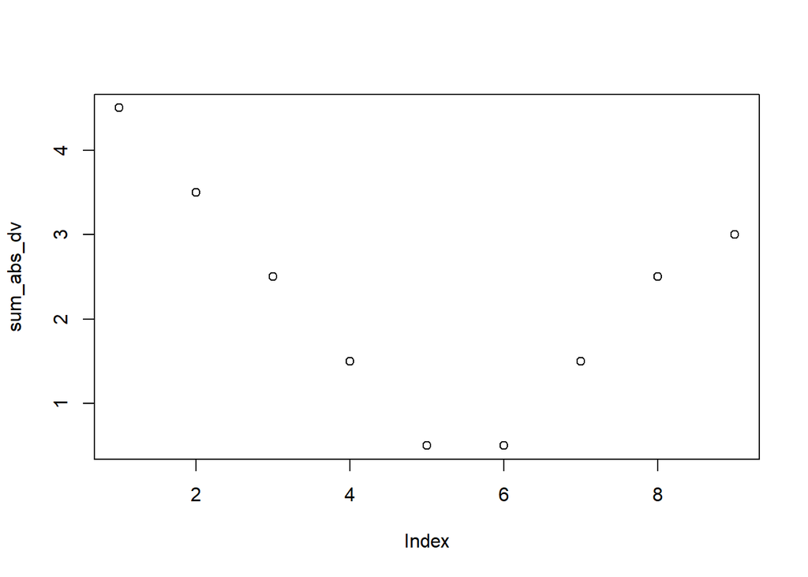

```r
plot(sum_abs_dv)
```

```r
mean(scores)
```

```
## [1] 5.5
```

```r
median(scores)
```

```
## [1] 6
```